# The Great Fertility Decline

A global data story on falling birth rates, 1960–2024

Author

Dillon Gregg · DATS 2102 Final Project

Published

May 8, 2026

Birth rates have fallen almost everywhere over the last sixty years. In 1960 the average woman had about five children. By 2024 that number had dropped below 2.3, which is barely above the 2.1 replacement rate needed to keep a population stable without immigration. Today, more than half of the world lives in a country where fertility is below replacement.

This notebook looks at how, where, and why this happened. The data comes from the World Bank, which publishes long-running indicators for around 200 countries.

> **Question.** Where has fertility fallen fastest, where has it stalled, and which factors track the change most closely?

## 1 · Setup

```python
# Imports & global plotting style.
from pathlib import Path
import warnings

import numpy as np
import pandas as pd
import matplotlib.pyplot as plt
import matplotlib as mpl
import seaborn as sns
import plotly.express as px
import plotly.io as pio

warnings.filterwarnings("ignore")
RNG = np.random.default_rng(2102)

# Accessibility-aware defaults (ColorBrewer-style, CVD-friendly).
sns.set_theme(
    context="talk",
    style="whitegrid",
    palette="colorblind",
    rc={
        "axes.titleweight": "bold",
        "axes.titlelocation": "left",
        "axes.spines.right": False,
        "axes.spines.top": False,
        "figure.dpi": 110,
        "savefig.dpi": 150,
        "savefig.bbox": "tight",
    },
)
pio.templates.default = "plotly_white"
PLOTLY_KW = dict(autosize=True, height=520)


def plotly_iframe(fig, height_px=560, title="Interactive map") -> str:
    # Hermetic iframe: the iframe owns its own <html>/<head>/<body>, so parent
    # page CSS, embed-resources processing, and Quarto's HTML mangling cannot
    # break Plotly's runtime measurement and rendering.
    inner = pio.to_html(
        fig,
        include_plotlyjs="cdn",
        full_html=True,
        config={"responsive": True, "displayModeBar": False},
        default_width="100%",
        default_height="100%",
    )
    # Escape for srcdoc attribute, only quotes need escaping (HTML-encode them).
    srcdoc = inner.replace("&", "&amp;").replace('"', "&quot;")
    return (
        f'<iframe title="{title}" srcdoc="{srcdoc}" '
        f'style="width:100%; height:{height_px}px; border:0; '
        f'border-radius:6px; background:#fff;" loading="lazy"></iframe>'
    )

DATA = Path("data/raw")
FIG = Path("figures"); FIG.mkdir(exist_ok=True)

# Reusable highlight palette (Okabe-Ito, CVD-safe).
PALETTE = {
    "Sub-Saharan Africa":  "#D55E00",
    "South Asia":          "#E69F00",
    "MENA":                "#CC79A7",
    "Latin America & Caribbean": "#009E73",
    "East Asia & Pacific": "#0072B2",
    "Europe & Central Asia": "#56B4E9",
    "North America":       "#7F7F7F",
}
REPLACEMENT = 2.1
```

## 2 · Data and wrangling

All indicators come from the World Bank Open Data API (`api.worldbank.org/v2`). The two fetch scripts in `scripts/` pull one CSV per indicator into `data/raw/` in long format. The cells below cover all of the wrangling primitives required by the rubric: selection and filtering, sorting, groupby with aggregation, joins, and a tidy reshape from long to wide for the correlation work later.

```python
# Load all indicator files into a single tidy long table.
INDICATORS = {
    "fertility_rate_total":        "Fertility rate (births per woman)",
    "life_expectancy":             "Life expectancy at birth (years)",
    "gdp_per_capita_usd":          "GDP per capita (current US$)",
    "secondary_enroll_female_pct": "Secondary enrolment, female (% gross)",
    "urban_pop_pct":               "Urban population (% of total)",
    "adolescent_fertility":        "Adolescent fertility (births / 1k women 15-19)",
    "infant_mortality":            "Infant mortality (per 1k live births)",
    "maternal_mortality_ratio":    "Maternal mortality ratio (per 100k live births)",
    "population_total":            "Population, total",
    "female_labor_force_pct":      "Female labour-force participation (% 15+)",
}

frames = []
for slug in INDICATORS:
    df = pd.read_csv(DATA / f"{slug}.csv")
    df["indicator_slug"] = slug
    frames.append(df)
long = pd.concat(frames, ignore_index=True)
print(f"Loaded {len(long):,} rows · {long['country_id'].nunique()} entities · "
      f"{long['indicator_slug'].nunique()} indicators · "
      f"years {long['year'].min()}-{long['year'].max()}")
long.head()
```

```
Loaded 175,560 rows · 266 entities · 10 indicators · years 1960-2025
```

|  | country | country_id | indicator_code | indicator_name | year | value | indicator_slug |
| --- | --- | --- | --- | --- | --- | --- | --- |
| 0 | Africa Eastern and Southern | AFE | SP.DYN.TFRT.IN | Fertility rate, total (births per woman) | 2025 | NaN | fertility_rate_total |
| 1 | Africa Eastern and Southern | AFE | SP.DYN.TFRT.IN | Fertility rate, total (births per woman) | 2024 | 4.164044 | fertility_rate_total |
| 2 | Africa Eastern and Southern | AFE | SP.DYN.TFRT.IN | Fertility rate, total (births per woman) | 2023 | 4.223861 | fertility_rate_total |
| 3 | Africa Eastern and Southern | AFE | SP.DYN.TFRT.IN | Fertility rate, total (births per woman) | 2022 | 4.287080 | fertility_rate_total |
| 4 | Africa Eastern and Southern | AFE | SP.DYN.TFRT.IN | Fertility rate, total (births per woman) | 2021 | 4.350691 | fertility_rate_total |

```python
# Country metadata: region & income group.
meta = pd.read_csv(DATA / "country_meta.csv")

# Region labels: shorter names for charts, group MENA, drop trailing space.
region_short = {
    "Latin America & Caribbean ":   "Latin America & Caribbean",
    "Sub-Saharan Africa ":          "Sub-Saharan Africa",
    "Middle East, North Africa, Afghanistan & Pakistan": "MENA",
    "Europe & Central Asia":        "Europe & Central Asia",
    "East Asia & Pacific":          "East Asia & Pacific",
    "South Asia":                   "South Asia",
    "North America":                "North America",
}
meta["region"] = meta["region"].map(region_short).fillna(meta["region"])

# SELECTION/FILTERING demo: drop the World Bank "aggregate" entities so we keep individual countries only.
countries = meta.loc[meta["region"] != "Aggregates", ["country_id", "country", "region",
                                                      "income_group", "longitude", "latitude"]]
print(f"{len(countries)} countries after dropping aggregates")
countries.head()
```

```
217 countries after dropping aggregates
```

|  | country_id | country | region | income_group | longitude | latitude |
| --- | --- | --- | --- | --- | --- | --- |
| 0 | ABW | Aruba | Latin America & Caribbean | High income | -70.0167 | 12.51670 |
| 2 | AFG | Afghanistan | MENA | Low income | 69.1761 | 34.52280 |
| 5 | AGO | Angola | Sub-Saharan Africa | Lower middle income | 13.2420 | -8.81155 |
| 6 | ALB | Albania | Europe & Central Asia | Upper middle income | 19.8172 | 41.33170 |
| 7 | AND | Andorra | Europe & Central Asia | High income | 1.5218 | 42.50750 |

```python
# JOIN/MERGE demo + reshape to a tidy panel: one row per (country, year),
# one column per indicator. This is the workhorse table for almost everything below.
panel = (
    long
    .pivot_table(index=["country_id", "country", "year"],
                 columns="indicator_slug", values="value", aggfunc="first")
    .reset_index()
    .merge(countries[["country_id", "region", "income_group"]],
           on="country_id", how="inner")  # keeps countries only, drops aggregates
)
panel.columns.name = None
panel = panel.sort_values(["country_id", "year"]).reset_index(drop=True)
print(f"Panel: {len(panel):,} country-years · {panel['country_id'].nunique()} countries")
panel.head()
```

```
Panel: 14,288 country-years · 217 countries
```

|  | country_id | country | year | adolescent_fertility | female_labor_force_pct | fertility_rate_total | gdp_per_capita_usd | infant_mortality | life_expectancy | maternal_mortality_ratio | population_total | secondary_enroll_female_pct | urban_pop_pct | region | income_group |
| --- | --- | --- | --- | --- | --- | --- | --- | --- | --- | --- | --- | --- | --- | --- | --- |
| 0 | ABW | Aruba | 1960 | 44.732 | NaN | 4.567 | NaN | NaN | 64.049 | NaN | 54922.0 | NaN | 59.023670 | Latin America & Caribbean | High income |
| 1 | ABW | Aruba | 1961 | 45.826 | NaN | 4.422 | NaN | NaN | 64.215 | NaN | 55578.0 | NaN | 59.072800 | Latin America & Caribbean | High income |
| 2 | ABW | Aruba | 1962 | 46.716 | NaN | 4.262 | NaN | NaN | 64.602 | NaN | 56320.0 | NaN | 59.212271 | Latin America & Caribbean | High income |
| 3 | ABW | Aruba | 1963 | 47.440 | NaN | 4.107 | NaN | NaN | 64.944 | NaN | 57002.0 | NaN | 59.432359 | Latin America & Caribbean | High income |
| 4 | ABW | Aruba | 1964 | 47.428 | NaN | 3.940 | NaN | NaN | 65.303 | NaN | 57619.0 | NaN | 59.723340 | Latin America & Caribbean | High income |

```python
# GROUPBY + AGGREGATION demo: population-weighted regional fertility, by year.
def weighted_mean(df, value_col, weight_col):
    w = df[weight_col]
    v = df[value_col]
    m = v.notna() & w.notna()
    return np.nan if not m.any() else float(np.average(v[m], weights=w[m]))

regional = (
    panel
    .dropna(subset=["fertility_rate_total"])
    .groupby(["region", "year"])
    .apply(lambda g: pd.Series({
        "fertility_pop_weighted": weighted_mean(g, "fertility_rate_total", "population_total"),
        "fertility_unweighted":   g["fertility_rate_total"].mean(),
        "fertility_p10":          g["fertility_rate_total"].quantile(0.10),
        "fertility_p90":          g["fertility_rate_total"].quantile(0.90),
        "n_countries":            g["fertility_rate_total"].notna().sum(),
    }))
    .reset_index()
)
regional.head()
```

|  | region | year | fertility_pop_weighted | fertility_unweighted | fertility_p10 | fertility_p90 | n_countries |
| --- | --- | --- | --- | --- | --- | --- | --- |
| 0 | East Asia & Pacific | 1960 | 4.583782 | 5.931027 | 4.3666 | 7.1146 | 37.0 |
| 1 | East Asia & Pacific | 1961 | 4.180293 | 5.863297 | 4.1312 | 7.1004 | 37.0 |
| 2 | East Asia & Pacific | 1962 | 5.622071 | 5.909027 | 4.3118 | 7.0644 | 37.0 |
| 3 | East Asia & Pacific | 1963 | 6.536458 | 5.913162 | 4.1562 | 7.1654 | 37.0 |
| 4 | East Asia & Pacific | 1964 | 5.994200 | 5.831541 | 3.8858 | 7.0586 | 37.0 |

```python
# SORTING demo: ten highest and ten lowest fertility countries in the most recent year
LATEST_YEAR = int(panel.dropna(subset=["fertility_rate_total"])["year"].max())
latest = panel[panel["year"] == LATEST_YEAR].dropna(subset=["fertility_rate_total"]).copy()
print(f"Latest complete-ish year used throughout: {LATEST_YEAR} "
      f"({latest['fertility_rate_total'].notna().sum()} countries reporting)")

top10 = latest.nlargest(10, "fertility_rate_total")[["country", "region", "fertility_rate_total"]]
bot10 = latest.nsmallest(10, "fertility_rate_total")[["country", "region", "fertility_rate_total"]]
display(top10.style.set_caption(f"Highest fertility, {LATEST_YEAR}").format({"fertility_rate_total": "{:.2f}"}))
display(bot10.style.set_caption(f"Lowest fertility, {LATEST_YEAR}").format({"fertility_rate_total": "{:.2f}"}))
```

```
Latest complete-ish year used throughout: 2024 (217 countries reporting)
```

Table 1: Highest fertility, 2024

|  | country | region | fertility_rate_total |
| --- | --- | --- | --- |
| 12442 | Chad | Sub-Saharan Africa | 6.03 |
| 11588 | Somalia, Fed. Rep. | Sub-Saharan Africa | 6.01 |
| 2633 | Congo, Dem. Rep. | Sub-Saharan Africa | 5.98 |
| 2105 | Central African Republic | Sub-Saharan Africa | 5.95 |
| 9348 | Niger | Sub-Saharan Africa | 5.93 |
| 8491 | Mali | Sub-Saharan Africa | 5.51 |
| 195 | Angola | Sub-Saharan Africa | 5.05 |
| 918 | Burundi | Sub-Saharan Africa | 4.79 |
| 129 | Afghanistan | MENA | 4.76 |
| 8886 | Mozambique | Sub-Saharan Africa | 4.69 |

Table 2: Lowest fertility, 2024

|  | country | region | fertility_rate_total |
| --- | --- | --- | --- |
| 7834 | Macao SAR, China | East Asia & Pacific | 0.58 |
| 6978 | Korea, Rep. | East Asia & Pacific | 0.75 |
| 5463 | Hong Kong SAR, China | East Asia & Pacific | 0.84 |
| 10403 | Puerto Rico (US) | Latin America & Caribbean | 0.92 |
| 11259 | Singapore | East Asia & Pacific | 0.97 |
| 13299 | Ukraine | Europe & Central Asia | 0.99 |
| 8557 | Malta | MENA | 1.01 |
| 2435 | China | East Asia & Pacific | 1.01 |
| 13694 | British Virgin Islands | Latin America & Caribbean | 1.05 |
| 327 | Andorra | Europe & Central Asia | 1.09 |

## 3 · The big picture, six decades of decline

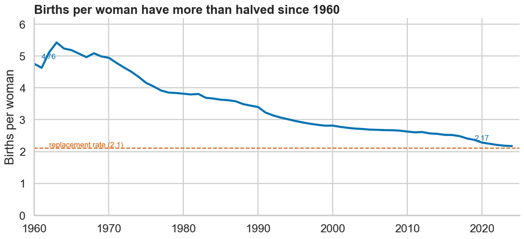

```python
# Figure 1: Global population-weighted fertility, 1960-LATEST
global_series = (
    panel.dropna(subset=["fertility_rate_total"])
    .groupby("year")
    .apply(lambda g: weighted_mean(g, "fertility_rate_total", "population_total"))
    .rename("fertility_pop_weighted").reset_index()
)

fig, ax = plt.subplots(figsize=(11, 5.2))
ax.plot(global_series["year"], global_series["fertility_pop_weighted"],
        color="#0072B2", lw=3, label="Global, population-weighted")
ax.axhline(REPLACEMENT, color="#D55E00", lw=1.5, ls="--")
ax.text(1962, REPLACEMENT + 0.05, f"replacement rate ({REPLACEMENT})",
        color="#D55E00", fontsize=11)

# Annotate start and end values
y0 = float(global_series.iloc[0]["fertility_pop_weighted"])
y1 = float(global_series.dropna().iloc[-1]["fertility_pop_weighted"])
yr_end = int(global_series.dropna().iloc[-1]["year"])
ax.annotate(f"{y0:.2f}", (1960, y0), xytext=(1961, y0 + 0.15), fontsize=11, color="#0072B2")
ax.annotate(f"{y1:.2f}", (yr_end, y1), xytext=(yr_end - 5, y1 + 0.18), fontsize=11, color="#0072B2")

ax.set_title("Births per woman have more than halved since 1960")
ax.set_ylabel("Births per woman")
ax.set_xlabel("")
ax.set_ylim(0, 6.2)
ax.set_xlim(1960, yr_end + 1)
plt.tight_layout()
plt.savefig(FIG / "01_global_trend.png")
plt.show()
```

**Figure 1.** Population-weighted global total fertility rate, 1960 to the most recent year on file. The world average roughly halved over six decades. The dashed orange line at 2.1 marks long-run replacement. Data: World Bank indicator `SP.DYN.TFRT.IN`.

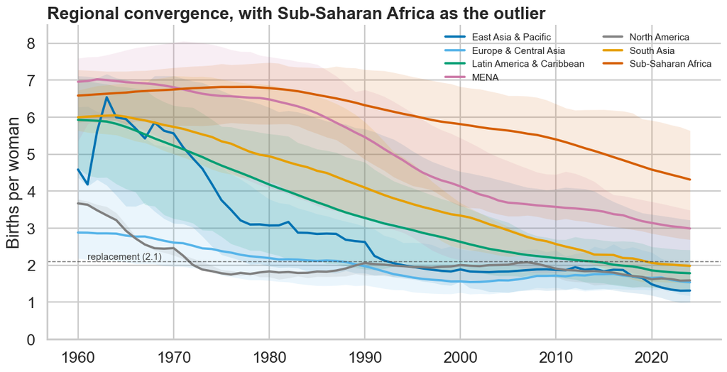

```python
# Figure 2: Regional trajectories with uncertainty band (P10-P90)
fig, ax = plt.subplots(figsize=(11, 5.8))
for region, sub in regional.sort_values("year").groupby("region"):
    color = PALETTE.get(region, "#444")
    ax.fill_between(sub["year"], sub["fertility_p10"], sub["fertility_p90"],
                    color=color, alpha=0.12, linewidth=0)
    ax.plot(sub["year"], sub["fertility_pop_weighted"],
            color=color, lw=2.4, label=region)

ax.axhline(REPLACEMENT, color="#444", lw=1, ls="--", alpha=0.7)
ax.text(1961, REPLACEMENT + 0.05, "replacement (2.1)", fontsize=10, color="#444")
ax.set_title("Regional convergence, with Sub-Saharan Africa as the outlier")
ax.set_ylabel("Births per woman")
ax.set_xlabel("")
ax.set_ylim(0, 8.5)
ax.legend(loc="upper right", frameon=False, fontsize=10, ncol=2)
plt.tight_layout()
plt.savefig(FIG / "02_regional_trends.png")
plt.show()
```

**Figure 2.** Population-weighted regional fertility, with shaded bands showing the 10th to 90th percentile range of country values inside each region. Five of the seven regions are now at or below replacement. Sub-Saharan Africa is the clear outlier, still above 4. The shaded band is there so the chart shows how much variation each line is averaging over.

## 4 · Where the decline is happening

Two maps go here. The first is a snapshot of the most recent year. The second is an animated version that scrubs through every five years from 1960, so you can watch the world change colour over time.

```python
# Figure 3: Static choropleth, latest year
map_latest = panel[panel["year"] == LATEST_YEAR].dropna(subset=["fertility_rate_total"]).copy()
fig3 = px.choropleth(
    map_latest,
    locations="country_id",
    color="fertility_rate_total",
    hover_name="country",
    hover_data={"country_id": False, "region": True,
                "fertility_rate_total": ":.2f"},
    color_continuous_scale="RdYlBu_r",
    range_color=(1.0, 7.0),
    labels={"fertility_rate_total": "Births / woman"},
    title=f"Total fertility rate by country, {LATEST_YEAR}",
)
fig3.update_layout(**PLOTLY_KW, margin=dict(l=0, r=0, t=60, b=0),
                   coloraxis_colorbar=dict(title="Births<br>per woman"))
fig3.write_html(str(FIG / "03_choropleth_latest.html"), include_plotlyjs="cdn")

# Hermetic iframe embed (see plotly_iframe docstring for why).
from IPython.display import HTML, display
display(HTML(f'<div class="plotly-wrap">{plotly_iframe(fig3, height_px=560, title="Choropleth: total fertility rate, latest year")}</div>'))
```

[interactive chart not shown]

```python
# Figure 4: Animated choropleth: every 5 years, 1960 -> latest
years_anim = list(range(1960, LATEST_YEAR + 1, 5))
if LATEST_YEAR not in years_anim:
    years_anim.append(LATEST_YEAR)
anim_df = panel[panel["year"].isin(years_anim)].dropna(subset=["fertility_rate_total"]).copy()

fig4 = px.choropleth(
    anim_df.sort_values("year"),
    locations="country_id",
    color="fertility_rate_total",
    hover_name="country",
    animation_frame="year",
    color_continuous_scale="RdYlBu_r",
    range_color=(1.0, 8.0),
    labels={"fertility_rate_total": "Births / woman"},
    title="Six decades of falling fertility (5-year frames)",
)
fig4.update_layout(**PLOTLY_KW, margin=dict(l=0, r=0, t=60, b=0))
fig4.write_html(str(FIG / "04_choropleth_animated.html"), include_plotlyjs="cdn")
display(HTML(f'<div class="plotly-wrap">{plotly_iframe(fig4, height_px=600, title="Animated choropleth: 1960-latest")}</div>'))
```

[interactive chart not shown]

**Figure 4.** Animated choropleth at 5-year intervals from 1960 to the latest year. Press play, or drag the slider. The reds and oranges drain out of East Asia first (1970s and 1980s), then Latin America and South Asia. Sub-Saharan Africa lightens too, just much more slowly.

## 5 · Crossing the replacement line

How much of the world now lives in a country with fertility below replacement? In 1960 the answer was close to zero. Today it is most of us.

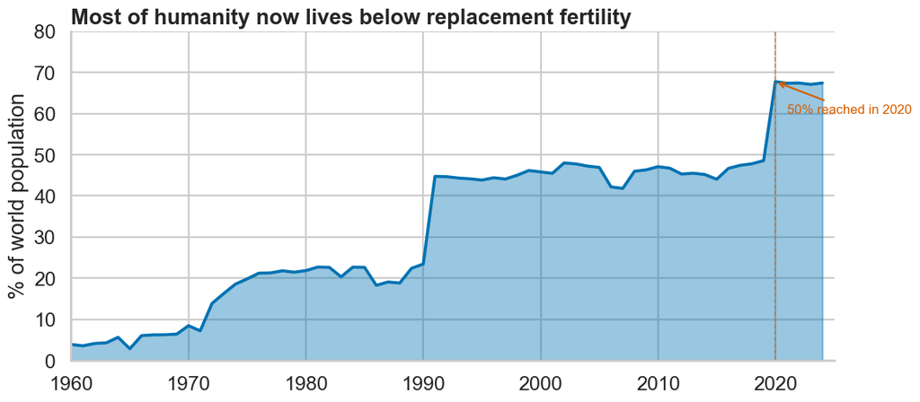

```python
# Figure 5: Share of global population living below replacement
def share_below(df, threshold=REPLACEMENT):
    d = df.dropna(subset=["fertility_rate_total", "population_total"])
    total = d["population_total"].sum()
    below = d.loc[d["fertility_rate_total"] < threshold, "population_total"].sum()
    return below / total if total else np.nan

share = (
    panel.groupby("year").apply(share_below).rename("share_below_replacement").reset_index()
)

fig, ax = plt.subplots(figsize=(11, 5))
ax.fill_between(share["year"], 0, share["share_below_replacement"] * 100,
                color="#0072B2", alpha=0.4)
ax.plot(share["year"], share["share_below_replacement"] * 100,
        color="#0072B2", lw=2.5)
# annotate crossing year of 50 %
crossed = share[share["share_below_replacement"] >= 0.5]
if not crossed.empty:
    cy = int(crossed.iloc[0]["year"])
    cs = float(crossed.iloc[0]["share_below_replacement"]) * 100
    ax.axvline(cy, color="#D55E00", lw=1, ls="--", alpha=0.7)
    ax.annotate(f"50% reached in {cy}",
                xy=(cy, cs), xytext=(cy + 1, 60),
                arrowprops=dict(arrowstyle="->", color="#D55E00"),
                fontsize=11, color="#D55E00")

ax.set_title("Most of humanity now lives below replacement fertility")
ax.set_ylabel("% of world population")
ax.set_xlabel("")
ax.set_ylim(0, 80)
ax.set_xlim(1960, share["year"].max())
plt.tight_layout()
plt.savefig(FIG / "05_share_below_replacement.png")
plt.show()
```

**Figure 5.** Share of the world’s population living in a country with TFR below 2.1. The line goes from almost zero in 1960 to a clear majority today. The biggest single jump came when China crossed the threshold in the early 1990s, and another arrives when India crosses in the 2020s. The numbers before about 1965 are noisy because the indicator’s country coverage was thinner back then.

## 6 · What tracks the decline?

Demographers usually point to a handful of variables that move with fertility: income, female education, female labour-force participation, and infant mortality (parents need fewer births to reach a target family size when more children survive). The next chart plots fertility against each of those, using the latest cross-section.

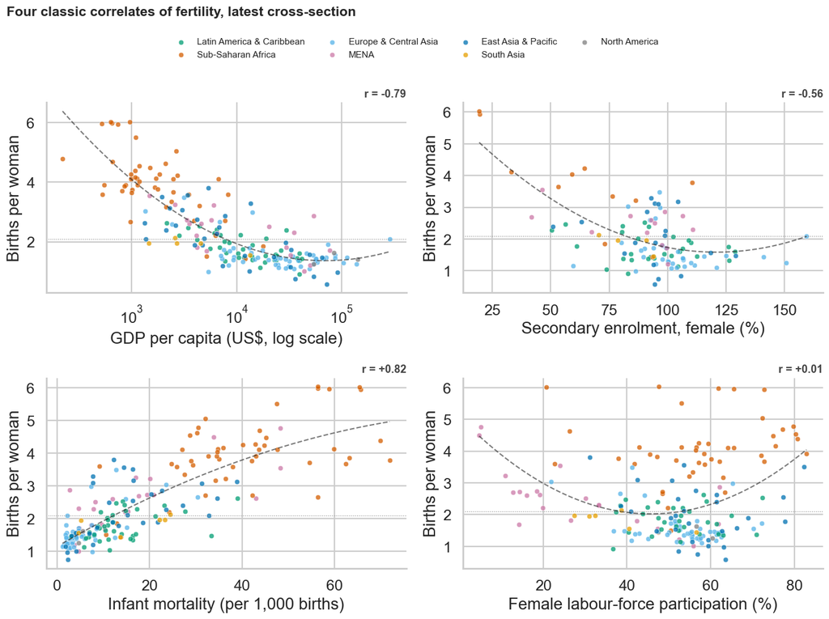

```python
# Figure 6: Four-panel scatter of fertility vs candidate drivers
drivers = [
    ("gdp_per_capita_usd",          "GDP per capita (US$, log scale)",      True),
    ("secondary_enroll_female_pct", "Secondary enrolment, female (%)",      False),
    ("infant_mortality",            "Infant mortality (per 1,000 births)",  False),
    ("female_labor_force_pct",      "Female labour-force participation (%)",False),
]
cross = panel[panel["year"] == LATEST_YEAR].copy()
# fall back to most recent non-null for sparsely reported variables
for col, _, _ in drivers:
    if cross[col].notna().sum() < 80:
        recent = (panel.dropna(subset=[col])
                       .sort_values("year").groupby("country_id").tail(1)
                       [["country_id", col]])
        cross = cross.drop(columns=[col]).merge(recent, on="country_id", how="left")

fig, axes = plt.subplots(2, 2, figsize=(13, 9))
axes = axes.flatten()
for ax, (col, label, log_x) in zip(axes, drivers):
    sub = cross.dropna(subset=[col, "fertility_rate_total", "region"])
    for region in sub["region"].unique():
        s = sub[sub["region"] == region]
        ax.scatter(s[col], s["fertility_rate_total"],
                   s=30, alpha=0.75, color=PALETTE.get(region, "#888"),
                   edgecolor="white", linewidth=0.4, label=region)
    if log_x:
        ax.set_xscale("log")
    # LOWESS-ish trend via numpy polyfit on log/linear x
    x = np.log(sub[col]) if log_x else sub[col].astype(float)
    y = sub["fertility_rate_total"].astype(float)
    if len(x) > 5:
        coefs = np.polyfit(x, y, 2)
        xs = np.linspace(x.min(), x.max(), 120)
        ax.plot(np.exp(xs) if log_x else xs, np.polyval(coefs, xs),
                color="#222", lw=1.4, ls="--", alpha=0.6)
    ax.axhline(REPLACEMENT, color="#888", lw=0.8, ls=":")
    ax.set_xlabel(label)
    ax.set_ylabel("Births per woman")
    # Compute a simple Pearson r for the title
    from scipy.stats import pearsonr  # noqa: WPS433
    r, _ = pearsonr(x, y)
    ax.set_title(f"r = {r:+.2f}", fontsize=12, loc="right", color="#444")

# single shared legend
handles, labels = axes[0].get_legend_handles_labels()
fig.legend(handles, labels, loc="upper center", ncol=4, frameon=False,
           bbox_to_anchor=(0.5, 1.02), fontsize=10)
fig.suptitle("Four classic correlates of fertility, latest cross-section",
             fontsize=15, x=0.02, ha="left", y=1.06, fontweight="bold")
plt.tight_layout()
plt.savefig(FIG / "06_drivers_scatter.png")
plt.show()
```

**Figure 6.** Cross-country scatter plots of fertility against four candidate drivers, using the most recent year of data. Points are coloured by region. The dashed black curve in each panel is a quadratic fit on the appropriate axis (log for GDP, linear otherwise), and the $r$ value gives the simple Pearson correlation. Income and female schooling correlate negatively with fertility. Infant mortality correlates positively, since children dying pushes parents to have more. Female labour-force participation is messier and varies a lot by region. Sub-Saharan Africa has both high female employment and high fertility, which is why that panel’s correlation is weak.

## 7 · Distributions then and now

A single year is only a snapshot, so the next plot compares the country-level fertility distribution in 1965 against the most recent year, broken out by region. Every region has shifted left, but the shape of each one tells a slightly different story.

[figure not shown]

```python
# Figure 7: Ridgeline-style violin: fertility distribution 1965 vs recent, by region
years_to_show = [1965, LATEST_YEAR]
dist = panel[panel["year"].isin(years_to_show)].dropna(subset=["fertility_rate_total"]).copy()
dist["era"] = dist["year"].map({1965: "1965", LATEST_YEAR: f"{LATEST_YEAR}"})

# region order: by 1965 median descending so the plot reads top-to-bottom
order = (dist[dist["year"] == 1965]
         .groupby("region")["fertility_rate_total"].median()
         .sort_values(ascending=False).index.tolist())

fig, ax = plt.subplots(figsize=(11.5, 6.2))
sns.violinplot(
    data=dist, x="fertility_rate_total", y="region", hue="era",
    order=order, split=True, inner="quartile", cut=0,
    palette={"1965": "#999", f"{LATEST_YEAR}": "#0072B2"}, ax=ax,
)
ax.axvline(REPLACEMENT, color="#D55E00", lw=1.2, ls="--")
ax.text(REPLACEMENT + 0.1, -0.45, f"replacement ({REPLACEMENT})",
        color="#D55E00", fontsize=10)
ax.set_title("Every region has shifted left, and Sub-Saharan Africa today sits where Asia was in 1965")
ax.set_xlabel("Births per woman")
ax.set_ylabel("")
ax.legend(title="", frameon=False, loc="lower right")
plt.tight_layout()
plt.savefig(FIG / "07_distribution_shift.png")
plt.show()
```

## 8 · Six country case studies

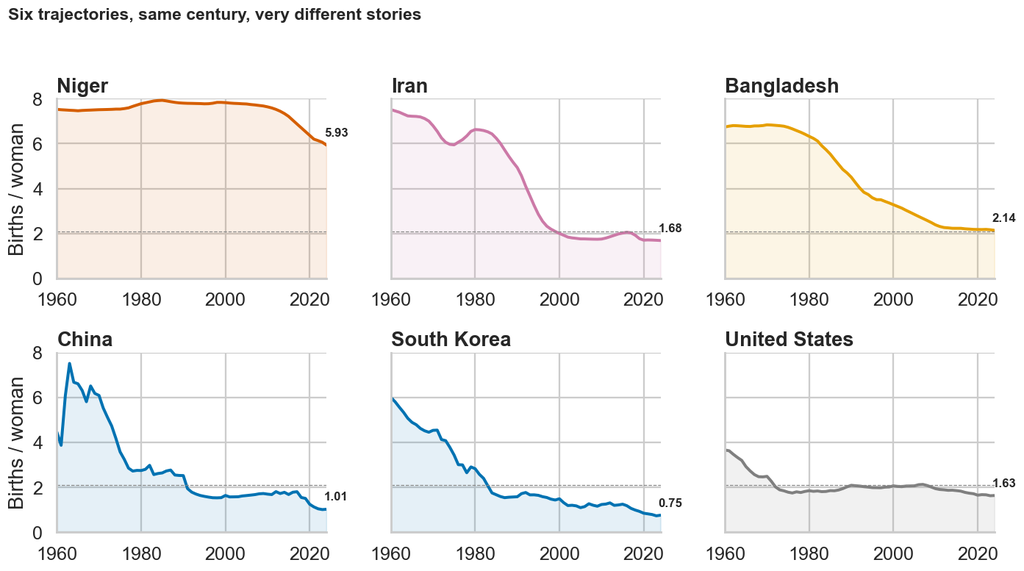

```python
# Figure 8: Small multiples of country trajectories
case_studies = ["NER", "IRN", "BGD", "CHN", "KOR", "USA"]
labels = {"NER": "Niger", "IRN": "Iran", "BGD": "Bangladesh",
          "CHN": "China", "KOR": "South Korea", "USA": "United States"}

cs = panel[panel["country_id"].isin(case_studies)].dropna(subset=["fertility_rate_total"])

fig, axes = plt.subplots(2, 3, figsize=(13, 7), sharey=True)
for ax, code3 in zip(axes.flatten(), case_studies):
    sub = cs[cs["country_id"] == code3].sort_values("year")
    ax.plot(sub["year"], sub["fertility_rate_total"],
            color=PALETTE.get(sub["region"].iloc[0], "#0072B2"), lw=2.6)
    ax.fill_between(sub["year"], 0, sub["fertility_rate_total"],
                    color=PALETTE.get(sub["region"].iloc[0], "#0072B2"), alpha=0.10)
    ax.axhline(REPLACEMENT, color="#888", lw=0.8, ls="--")
    last = sub.iloc[-1]
    ax.annotate(f"{last['fertility_rate_total']:.2f}",
                xy=(last["year"], last["fertility_rate_total"]),
                xytext=(-2, 8), textcoords="offset points",
                fontsize=11, fontweight="bold")
    ax.set_title(labels[code3])
    ax.set_xlim(1960, LATEST_YEAR)
    ax.set_ylim(0, 8)

for ax in axes[-1]:
    ax.set_xlabel("")
for ax in axes[:, 0]:
    ax.set_ylabel("Births / woman")

fig.suptitle("Six trajectories, same century, very different stories",
             fontsize=15, x=0.02, ha="left", y=1.02, fontweight="bold")
plt.tight_layout()
plt.savefig(FIG / "08_country_case_studies.png")
plt.show()
```

## 9 · The extremes today

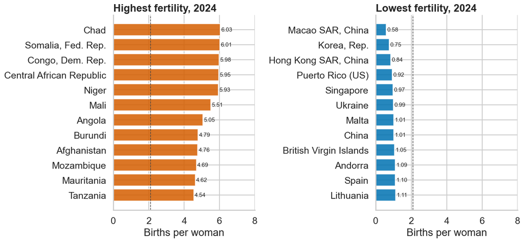

```python
# Figure 9: Top / bottom 12 dumbbell-style bar chart for latest year
N = 12
top = latest.nlargest(N, "fertility_rate_total")
bot = latest.nsmallest(N, "fertility_rate_total").iloc[::-1]

fig, axes = plt.subplots(1, 2, figsize=(13, 6.2), sharex=False)
for ax, df, title, color in [
    (axes[0], top, f"Highest fertility, {LATEST_YEAR}",  "#D55E00"),
    (axes[1], bot, f"Lowest fertility, {LATEST_YEAR}",   "#0072B2"),
]:
    ax.barh(df["country"], df["fertility_rate_total"], color=color, alpha=0.85)
    ax.axvline(REPLACEMENT, color="#444", lw=1, ls="--")
    for y, v in zip(df["country"], df["fertility_rate_total"]):
        ax.text(v + 0.05, y, f"{v:.2f}", va="center", fontsize=10)
    ax.set_title(title)
    ax.set_xlabel("Births per woman")
    ax.set_xlim(0, max(top["fertility_rate_total"].max(), 7) + 1)

axes[0].invert_yaxis()
plt.tight_layout()
plt.savefig(FIG / "09_top_bottom.png")
plt.show()
```

## 10 · A simple multivariate view

Reshaping the panel down to a per-country snapshot makes it easy to look at how all the indicators move together. The matrix below is a Pearson correlation across the most recent country-level cross-section, with log GDP.

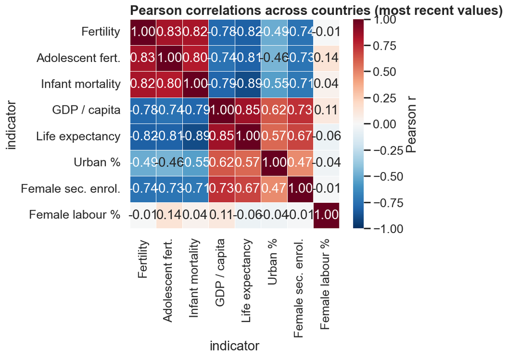

```python
# Figure 10: Correlation heatmap
num_cols = ["fertility_rate_total", "gdp_per_capita_usd",
            "secondary_enroll_female_pct", "infant_mortality",
            "life_expectancy", "urban_pop_pct", "female_labor_force_pct",
            "adolescent_fertility"]
nice = {
    "fertility_rate_total":         "Fertility",
    "gdp_per_capita_usd":           "GDP / capita",
    "secondary_enroll_female_pct":  "Female sec. enrol.",
    "infant_mortality":             "Infant mortality",
    "life_expectancy":              "Life expectancy",
    "urban_pop_pct":                "Urban %",
    "female_labor_force_pct":       "Female labour %",
    "adolescent_fertility":         "Adolescent fert.",
}

# TIDY RESHAPE demo: take latest non-null per (country, indicator) wide table.
recent_wide = (
    panel[num_cols + ["country_id"]]
    .melt(id_vars="country_id", var_name="indicator", value_name="value")
    .dropna(subset=["value"])
    .sort_values("country_id")
    .groupby(["country_id", "indicator"]).tail(1)
    .pivot(index="country_id", columns="indicator", values="value")
)
# log GDP for a more meaningful linear correlation
recent_wide["gdp_per_capita_usd"] = np.log(recent_wide["gdp_per_capita_usd"])
corr = recent_wide.rename(columns=nice).corr()
order = ["Fertility", "Adolescent fert.", "Infant mortality", "GDP / capita",
         "Life expectancy", "Urban %", "Female sec. enrol.", "Female labour %"]
corr = corr.loc[order, order]

fig, ax = plt.subplots(figsize=(8.5, 7))
sns.heatmap(corr, annot=True, fmt=".2f", cmap="RdBu_r", center=0,
            vmin=-1, vmax=1, square=True, linewidths=0.5,
            cbar_kws={"label": "Pearson r"}, ax=ax)
ax.set_title("Pearson correlations across countries (most recent values)")
plt.tight_layout()
plt.savefig(FIG / "10_correlation.png")
plt.show()
```

**Figure 10.** Cross-country Pearson correlations. Fertility’s strongest positive correlations are with infant mortality and adolescent fertility, both around +0.8. Its strongest negative correlations are with life expectancy and log GDP per capita, both around -0.8. Female labour-force participation is the weakest predictor in the matrix, which lines up with the messy regional pattern in Figure 6.

## 11 · A small predictive model

To close, a quick supervised-learning sanity check. I fit a Ridge regression that predicts a country’s fertility from its other indicators on the latest cross-section, then look at the standardised coefficients to rank the predictors. This is not a causal estimate. It is just a way of asking which variables, taken together, leave the least residual.

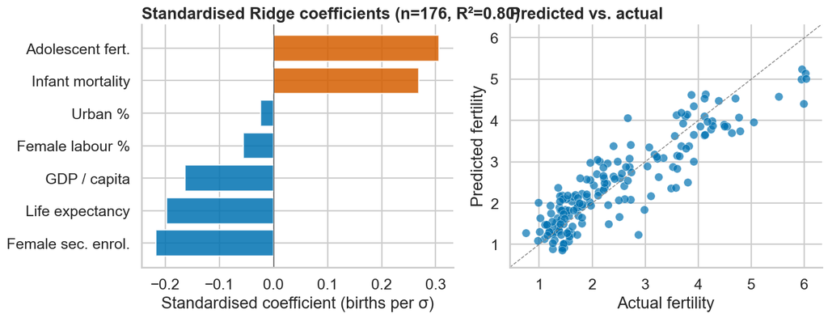

```
Best alpha: 31.6 · R² on training data: 0.804
```

```python
# Figure 11: Ridge regression coefficients (standardised inputs)
from sklearn.linear_model import RidgeCV
from sklearn.preprocessing import StandardScaler

features = ["gdp_per_capita_usd", "secondary_enroll_female_pct",
            "infant_mortality", "life_expectancy", "urban_pop_pct",
            "female_labor_force_pct", "adolescent_fertility"]

m = recent_wide.dropna(subset=features + ["fertility_rate_total"]).copy()
X = m[features].values
y = m["fertility_rate_total"].values

scaler = StandardScaler()
Xs = scaler.fit_transform(X)
model = RidgeCV(alphas=np.logspace(-3, 3, 25)).fit(Xs, y)
pred = model.predict(Xs)
r2 = model.score(Xs, y)

coefs = pd.Series(model.coef_, index=[nice[f] for f in features]).sort_values()
fig, axes = plt.subplots(1, 2, figsize=(13, 5.2))
colors = ["#D55E00" if c > 0 else "#0072B2" for c in coefs.values]
axes[0].barh(coefs.index, coefs.values, color=colors, alpha=0.85)
axes[0].axvline(0, color="#444", lw=0.8)
axes[0].set_title(f"Standardised Ridge coefficients (n={len(m)}, R²={r2:.2f})")
axes[0].set_xlabel("Standardised coefficient (births per σ)")

axes[1].scatter(y, pred, color="#0072B2", alpha=0.7, edgecolor="white", linewidth=0.4)
lim = (min(y.min(), pred.min()) - 0.3, max(y.max(), pred.max()) + 0.3)
axes[1].plot(lim, lim, color="#888", lw=1, ls="--")
axes[1].set_xlim(*lim); axes[1].set_ylim(*lim)
axes[1].set_xlabel("Actual fertility")
axes[1].set_ylabel("Predicted fertility")
axes[1].set_title("Predicted vs. actual")
plt.tight_layout()
plt.savefig(FIG / "11_ridge_model.png")
plt.show()
print(f"Best alpha: {model.alpha_:.3g} · R² on training data: {r2:.3f}")
```

## 12 · Limitations and ethics

- **Indicator definitions.** Total fertility rate is a period measure. It asks what would happen if today’s age-specific rates persisted for a synthetic cohort. That makes it sensitive to the timing of births, not just the quantity, which is why TFR can swing year to year (the European tempo effects in the 2010s and 2020s are a good example).
- **Coverage gaps.** Some countries report patchily. Small islands and conflict zones are the worst affected. In the cross-sectional figures (sections 10 and 11) I use the latest non-null value per country, which can introduce some comparability issues since “latest” varies.
- **Population weighting.** Population-weighted means are dominated by China and India, which is useful for describing what most humans experience but not great for comparing countries to each other.
- **Correlations are not causation.** Sections 6 and 11 are descriptive. The relationships are real but the channels are not identified, since income, schooling, and fertility all move together and could all be responding to something else.
- **Ethics.** All of the data is aggregated to the country level and contains no personal information. Cross-country comparisons should be careful not to flatten cultural and historical context, especially for regions that are still in the middle of their demographic transition.

## 13 · Takeaway

The fertility decline is not a future scenario, it is the current state of most of the world. The country-level data shows three things pretty clearly. First, the trend is global. Almost every region in this dataset has shifted left over six decades, and the holdouts are doing so on a delay rather than refusing to move. Second, the variables that track the change are the ones a development economist would predict, including infant mortality, female schooling, and income, with a few regional exceptions worth respecting. Third, the centre of gravity has moved from “how do we get fertility to fall” to “what happens when it stays low for a long time.”

## 14 · Reproducing this notebook

```
pip install pandas numpy matplotlib seaborn plotly scikit-learn scipy
python scripts/fetch_data.py          # ~30s, hits the World Bank API
python scripts/fetch_country_meta.py
jupyter nbconvert --to notebook --execute fertility_story.ipynb --inplace
quarto render fertility_story.ipynb --to html
```